# Practical Machine Learning Course Project

Tony Dreher

Wednesday, June 10, 2015

# Final Project Report - Practical Machine Learning Course

Tony Dreher

## Introduction

Using devices such as Jawbone Up, Nike FuelBand, and Fitbit it is now possible to collect a large amount of data about personal activity relatively inexpensively. These type of devices are part of the quantified self movement - a group of enthusiasts who take measurements about themselves regularly to improve their health, to find patterns in their behavior, or because they are tech geeks. One thing that people regularly do is quantify how much of a particular activity they do, but they rarely quantify how well they do it. In this project, your goal will be to use data from accelerometers on the belt, forearm, arm, and dumbell of 6 participants. They were asked to perform barbell lifts correctly and incorrectly in 5 different ways. More information is available from the website here: http://groupware.les.inf.puc-rio.br/har (see the section on the Weight Lifting Exercise Dataset).

## Project Intended Results

The goal of your project is to predict the manner in which they did the exercise. This is the “classe” variable in the training set. You may use any of the other variables to predict with. You should create a report describing how you built your model, how you used cross validation, what you think the expected out of sample error is, and why you made the choices you did. You will also use your prediction model to predict 20 different test cases.

## Reproduceablity

The following libraries were used for this project. The corresponding packages may need to be installed before loading the libraries.

```r
library(caret)
library(rpart)
library(rpart.plot)
library(RColorBrewer)
library(rattle)
library(randomForest)
```

The following seed will be used for the purposes of reproducability.

```r
set.seed(666)
```

## Data

A training dataset and testing dataset have been provided for this exercise.

```r
training <- read.csv(url("http://d396qusza40orc.cloudfront.net/predmachlearn/pml-training.csv"), na.strings=c("NA","#DIV/0!",""))
testing <- read.csv(url("http://d396qusza40orc.cloudfront.net/predmachlearn/pml-testing.csv"), na.strings=c("NA","#DIV/0!",""))
```

## Cleaning the data

The following transformations were used to clean the data:

The first seven columns will be removed as they are irrelevant to the study at hand.

```r
names(training)[1:7]
```

```
## [1] "X"                    "user_name"            "raw_timestamp_part_1"
## [4] "raw_timestamp_part_2" "cvtd_timestamp"       "new_window"
## [7] "num_window"
```

```r
training <- training[,-c(1:7)]
testing <- testing[,-c(1:7)]
dim(training);dim(testing)
```

```
## [1] 19622   153
```

```
## [1]  20 153
```

Variables which have more than a 60% threshold of NAs will also be removed.

```r
training <-training[,colSums(!is.na(training))/nrow(training) >= 0.6]
testing <-testing[,colSums(!is.na(testing))/nrow(testing) >= 0.6]
dim(training);dim(testing)
```

```
## [1] 19622    53
```

```
## [1] 20 53
```

Variables which lack variability would usually be removed as well, but in this case, there are none.

```r
nzv <- nearZeroVar(training,saveMetrics = TRUE)
nzv[nzv$nzv == TRUE,]
```

```
## [1] freqRatio     percentUnique zeroVar       nzv
## <0 rows> (or 0-length row.names)
```

## Partioning the training set into two

Because the training set is so large and the testing set so small, a training subset is created with 60% of the original training data set to be used for training while the other 40% is used as an additional testing set before using the original testing data.

```r
inTrain <- createDataPartition(training$classe, p = .60,list = FALSE)
trainingsubset <- training[ inTrain,]
testingsubset <- training[-inTrain,]
```

## Decision Tree Model

Since the a categorical outcome is being predicted, the decision tree model implemented first using the method `rpart`.

```r
modFit<-train(classe~.,method="rpart", data=trainingsubset)
print(modFit,digits=3)
```

```
## CART
##
## 11776 samples
##    52 predictor
##     5 classes: 'A', 'B', 'C', 'D', 'E'
##
## No pre-processing
## Resampling: Bootstrapped (25 reps)
##
## Summary of sample sizes: 11776, 11776, 11776, 11776, 11776, 11776, ...
##
## Resampling results across tuning parameters:
##
##   cp      Accuracy  Kappa   Accuracy SD  Kappa SD
##   0.0354  0.513     0.3655  0.0166       0.0253
##   0.0614  0.417     0.2101  0.0635       0.1072
##   0.1138  0.323     0.0581  0.0410       0.0618
##
## Accuracy was used to select the optimal model using  the largest value.
## The final value used for the model was cp = 0.0354.
```

```r
print(modFit$finalModel)
```

```
## n= 11776
##
## node), split, n, loss, yval, (yprob)
##       * denotes terminal node
##
##  1) root 11776 8428 A (0.28 0.19 0.17 0.16 0.18)
##    2) roll_belt< 130.5 10801 7461 A (0.31 0.21 0.19 0.18 0.11)
##      4) pitch_forearm< -33.65 959    6 A (0.99 0.0063 0 0 0) *
##      5) pitch_forearm>=-33.65 9842 7455 A (0.24 0.23 0.21 0.2 0.12)
##       10) magnet_dumbbell_y< 426.5 8204 5886 A (0.28 0.18 0.24 0.19 0.11)
##         20) roll_forearm< 122.5 5045 2977 A (0.41 0.18 0.18 0.17 0.06) *
##         21) roll_forearm>=122.5 3159 2101 C (0.079 0.18 0.33 0.23 0.18) *
##       11) magnet_dumbbell_y>=426.5 1638  825 B (0.042 0.5 0.042 0.22 0.2) *
##    3) roll_belt>=130.5 975    8 E (0.0082 0 0 0 0.99) *
```

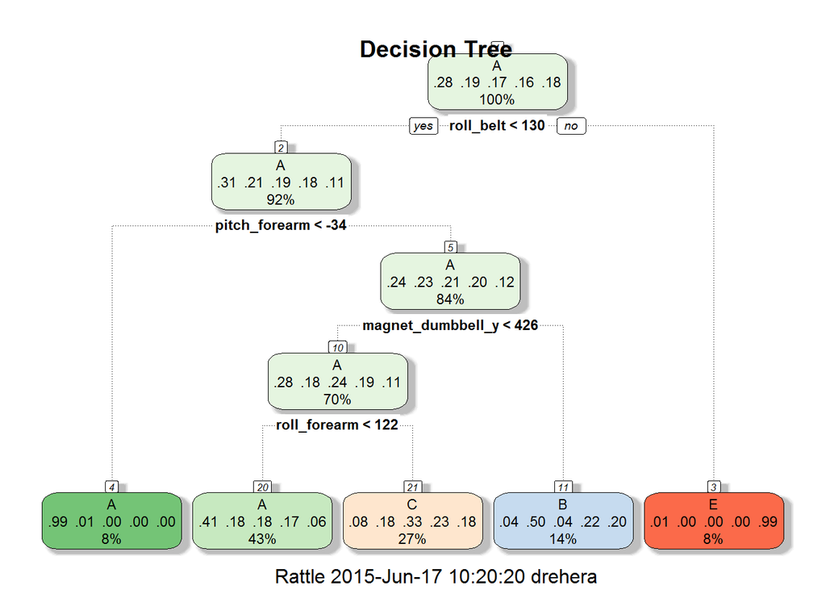

```r
fancyRpartPlot(modFit$finalModel,main="Decision Tree")
```

```r
classepredict <- predict(modFit,testingsubset)
confusionMatrix(testingsubset$classe,classepredict)
```

```
## Confusion Matrix and Statistics
##
##           Reference
## Prediction    A    B    C    D    E
##          A 2024   54  148    0    6
##          B  616  535  367    0    0
##          C  640   61  667    0    0
##          D  567  254  465    0    0
##          E  196  204  378    0  664
##
## Overall Statistics
##
##                Accuracy : 0.4958
##                  95% CI : (0.4847, 0.5069)
##     No Information Rate : 0.5153
##     P-Value [Acc > NIR] : 0.9997
##
##                   Kappa : 0.3412
##  Mcnemar's Test P-Value : NA
##
## Statistics by Class:
##
##                      Class: A Class: B Class: C Class: D Class: E
## Sensitivity            0.5006  0.48285  0.32938       NA  0.99104
## Specificity            0.9453  0.85411  0.87957   0.8361  0.89158
## Pos Pred Value         0.9068  0.35244  0.48757       NA  0.46047
## Neg Pred Value         0.6404  0.90945  0.79037       NA  0.99906
## Prevalence             0.5153  0.14122  0.25809   0.0000  0.08539
## Detection Rate         0.2580  0.06819  0.08501   0.0000  0.08463
## Detection Prevalence   0.2845  0.19347  0.17436   0.1639  0.18379
## Balanced Accuracy      0.7230  0.66848  0.60448       NA  0.94131
```

## Random Forest Model

Because the decision tree model was so inaccurate and the outcomes seem to be more nuanced than first suspected, a random forest model may be more appropriate.

```r
modFit2 <- train(classe ~ ., method="rf",trControl=trainControl(method = "cv", number = 4), data=trainingsubset)
print(modFit2,digits=3)
```

```
## Random Forest
##
## 11776 samples
##    52 predictor
##     5 classes: 'A', 'B', 'C', 'D', 'E'
##
## No pre-processing
## Resampling: Cross-Validated (4 fold)
##
## Summary of sample sizes: 8832, 8833, 8832, 8831
##
## Resampling results across tuning parameters:
##
##   mtry  Accuracy  Kappa  Accuracy SD  Kappa SD
##    2    0.988     0.985  0.00140      0.00177
##   27    0.987     0.984  0.00317      0.00401
##   52    0.978     0.972  0.00421      0.00533
##
## Accuracy was used to select the optimal model using  the largest value.
## The final value used for the model was mtry = 2.
```

```r
classepredict2 <- predict(modFit2,testingsubset)
confusionMatrix(testingsubset$classe,classepredict2)
```

```
## Confusion Matrix and Statistics
##
##           Reference
## Prediction    A    B    C    D    E
##          A 2227    5    0    0    0
##          B   16 1495    7    0    0
##          C    0   23 1341    4    0
##          D    0    0   27 1259    0
##          E    0    0    1    3 1438
##
## Overall Statistics
##
##                Accuracy : 0.989
##                  95% CI : (0.9865, 0.9912)
##     No Information Rate : 0.2859
##     P-Value [Acc > NIR] : < 2.2e-16
##
##                   Kappa : 0.9861
##  Mcnemar's Test P-Value : NA
##
## Statistics by Class:
##
##                      Class: A Class: B Class: C Class: D Class: E
## Sensitivity            0.9929   0.9816   0.9746   0.9945   1.0000
## Specificity            0.9991   0.9964   0.9958   0.9959   0.9994
## Pos Pred Value         0.9978   0.9848   0.9803   0.9790   0.9972
## Neg Pred Value         0.9971   0.9956   0.9946   0.9989   1.0000
## Prevalence             0.2859   0.1941   0.1754   0.1614   0.1833
## Detection Rate         0.2838   0.1905   0.1709   0.1605   0.1833
## Detection Prevalence   0.2845   0.1935   0.1744   0.1639   0.1838
## Balanced Accuracy      0.9960   0.9890   0.9852   0.9952   0.9997
```

The random forest model has a 99% accuracy - much better than the decision tree model. Additionally, the specificity and sensitivity is in the 90s across all 5 classes.

## Submission

```r
predictfinal <- predict(modFit2, newdata=testing)
predictfinal

pml_write_files = function(x){
  n = length(x)
  for(i in 1:n){
    filename = paste0("problem_id_",i,".txt")
    write.table(x[i],file=filename,quote=FALSE,row.names=FALSE,col.names=FALSE)
  }
}

pml_write_files(predictfinal)
```

[output not shown]